title: “hw6_Darshana_Daga” author: “Darshana” date: “5/19/2021”

#### Question1(a)

#### Setting up a random series

```r
#generating random series
#library
library(fpp2)
```

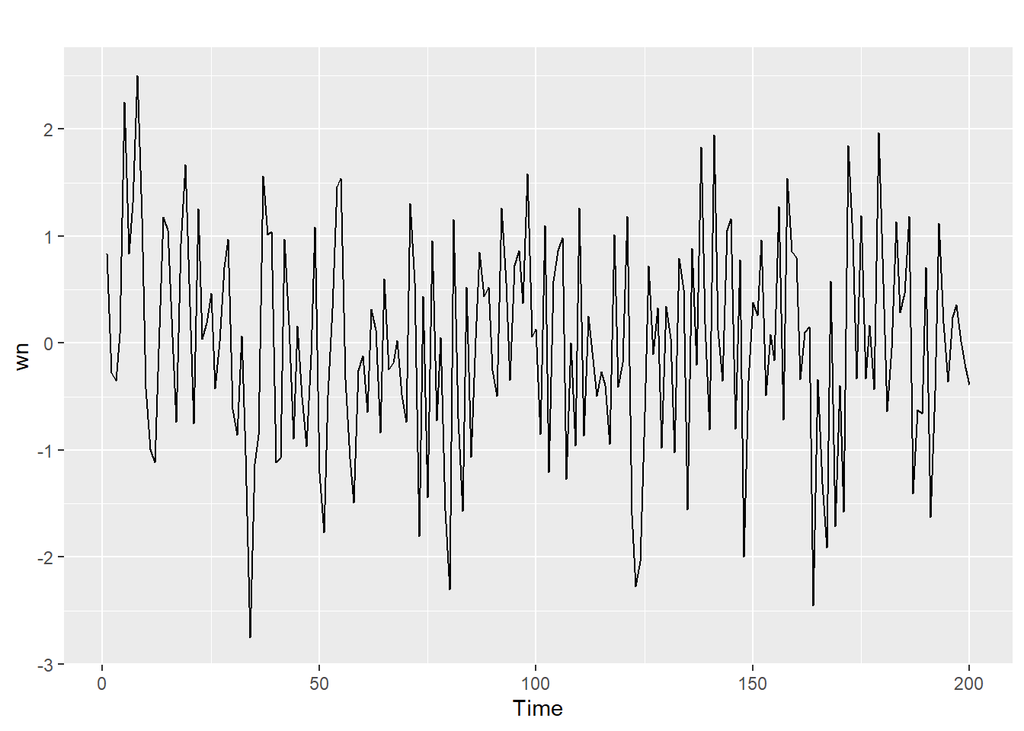

```r
set.seed(123456)
wn <- ts(data.frame(rnorm(200)))

autoplot(wn)
```

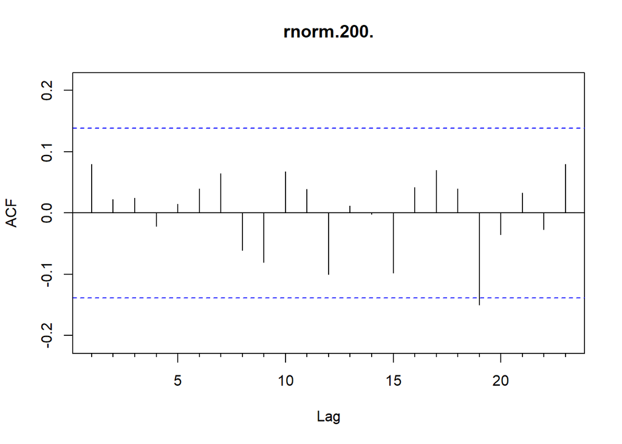

```r
#checking auto-correlation and partial auto-correlation
Acf(wn)
```

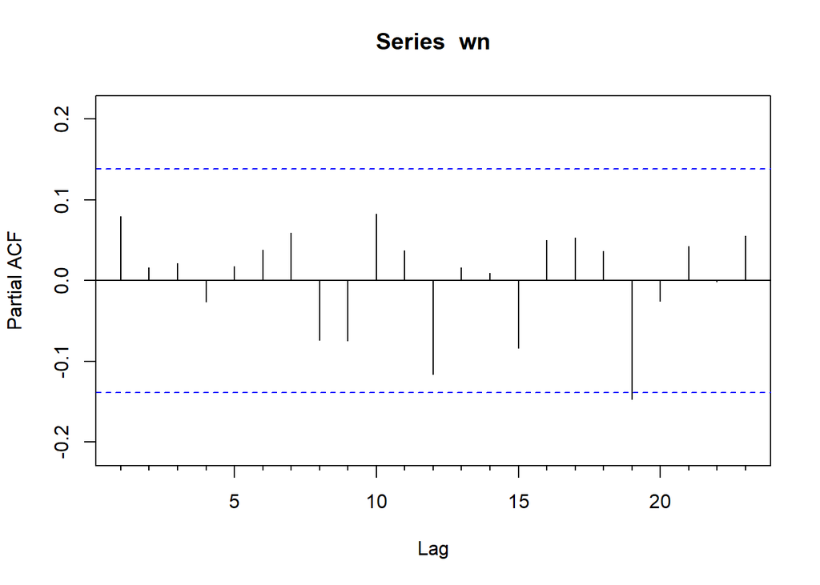

```r
Pacf(wn)
```

#### Question1(b)

##### b.AR(1) with parameter, 1 = 0.6

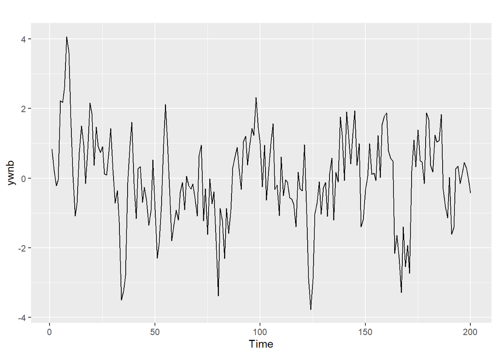

```r
ywnb <- ts(data.frame(matrix(rep(0),200,1)))
ywnb[1,1] <- wn[1]
for (i in 2:200) {
  ywnb[i,1] <- 0.6*ywnb[i-1,1] + wn[i]
}
autoplot(ywnb)
```

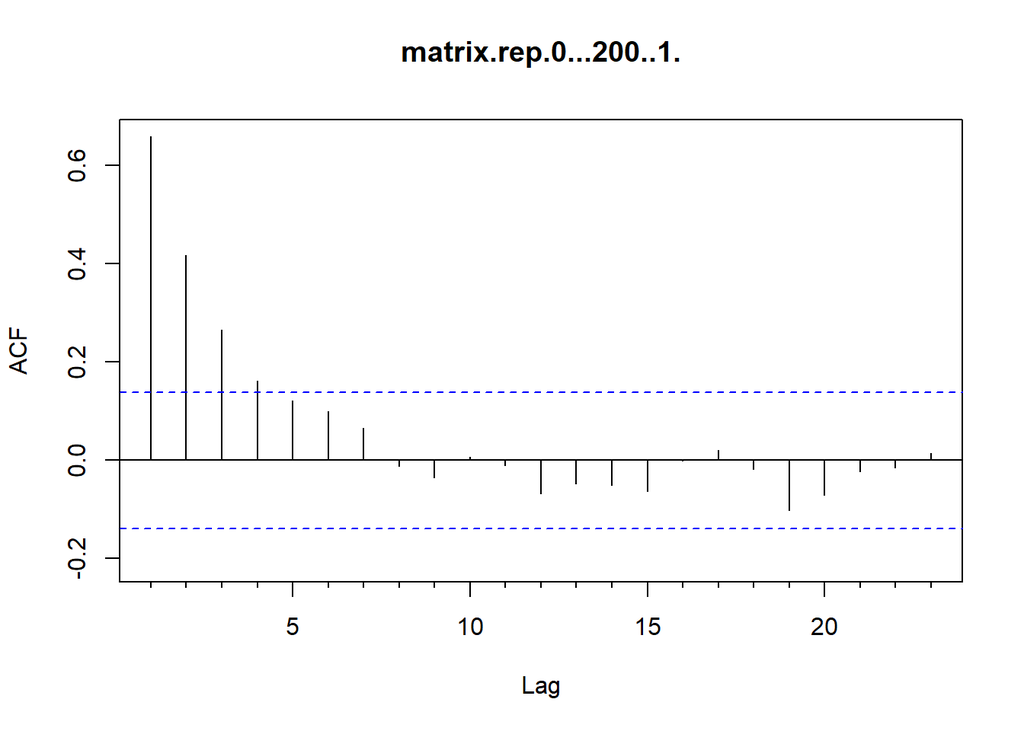

```r
#checking auto-correlation and partial auto-correlation
Acf(ywnb)
```

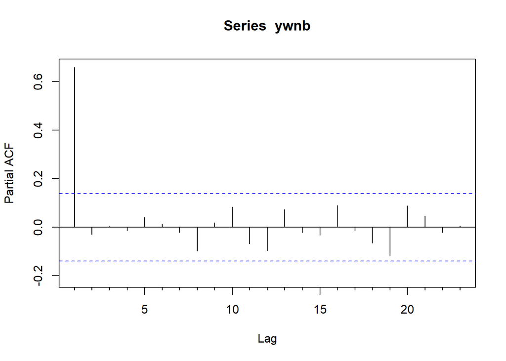

```r
Pacf(ywnb)
```

Auto-correlation can be noticed from lag 1 to 4 in the ACF, whereas with the PACF we can see that there is significant correlation with the residuals at lag 1,followed by non significant correlation showing an auto-regressive pattern.

#### Question1(c)

##### c.AR(2) with parameters, 1 = 0.6 and 2 = 0.3

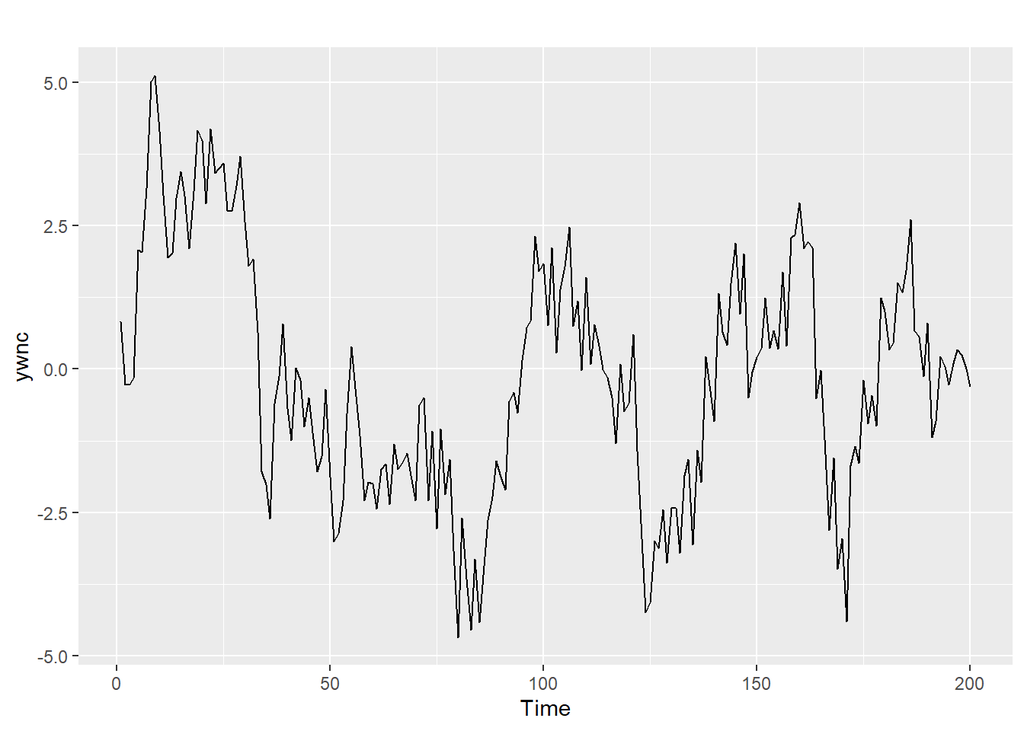

```r
ywnc <- ts(data.frame(matrix(rep(0),200,1)))
ywnc[1,1] <- wn[1]
ywnc[2,1] <- wn[2]
for (i in 3:200) {
  ywnc[i,1] <- 0.6*ywnc[i-1,1] +
     0.3*ywnc[i-2,1] + wn[i]
}
autoplot(ywnc)
```

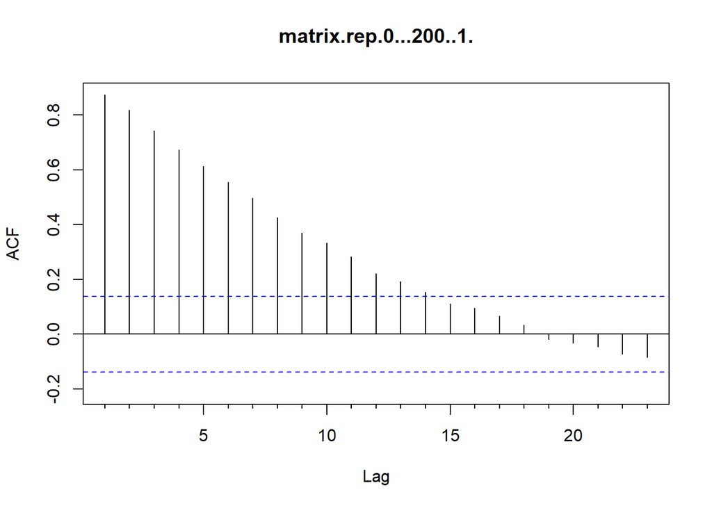

```r
#checking auto-correlation and partial auto-correlation
Acf(ywnc)
```

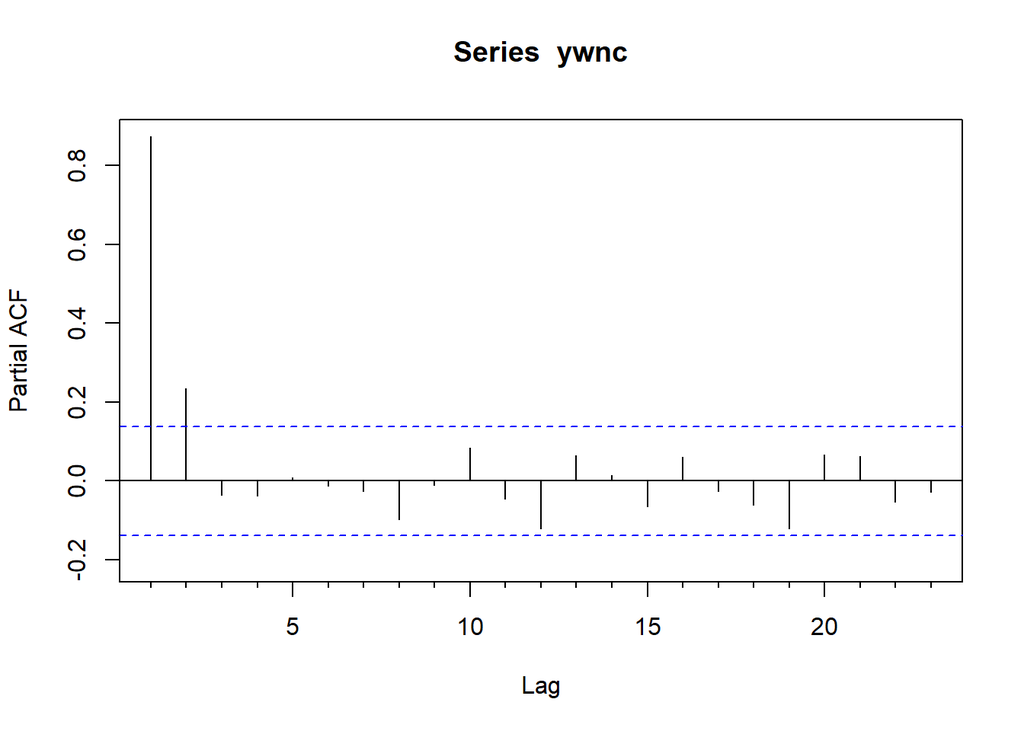

```r
Pacf(ywnc)
```

Auto-correlation can be noticed from lag 1 to 14 in the ACF, whereas with the PACF we can see that there is significant correlation with the residuals at lag 1 and lag2,followed by non significant correlation showing an auto-regressive pattern. The pacf has two bar above the significance line, which indicated its an AR2 model. With one bar close to 0.8 and the other is close to 0.25.

#### Question1(d)

##### d.AR(2) with parameters, 1 = 0.8 and 2 = – 0.3

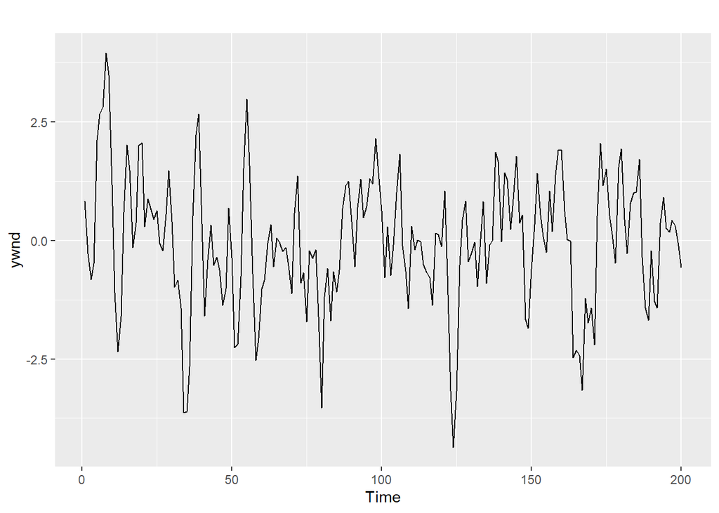

```r
ywnd <- ts(data.frame(matrix(rep(0),200,1)))
ywnd[1,1] <- wn[1]
ywnd[2,1] <- wn[2]
for (i in 3:200) {
  ywnd[i,1] <- 0.8*ywnd[i-1,1] +
    - 0.3*ywnd[i-2,1] + wn[i]
}
autoplot(ywnd)
```

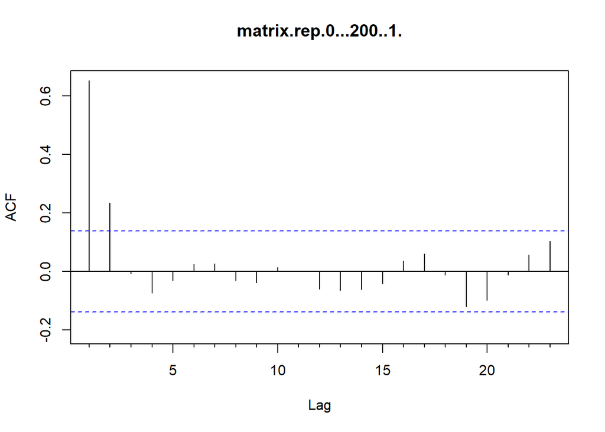

```r
#checking auto-correlation and partial auto-correlation
Acf(ywnd)
```

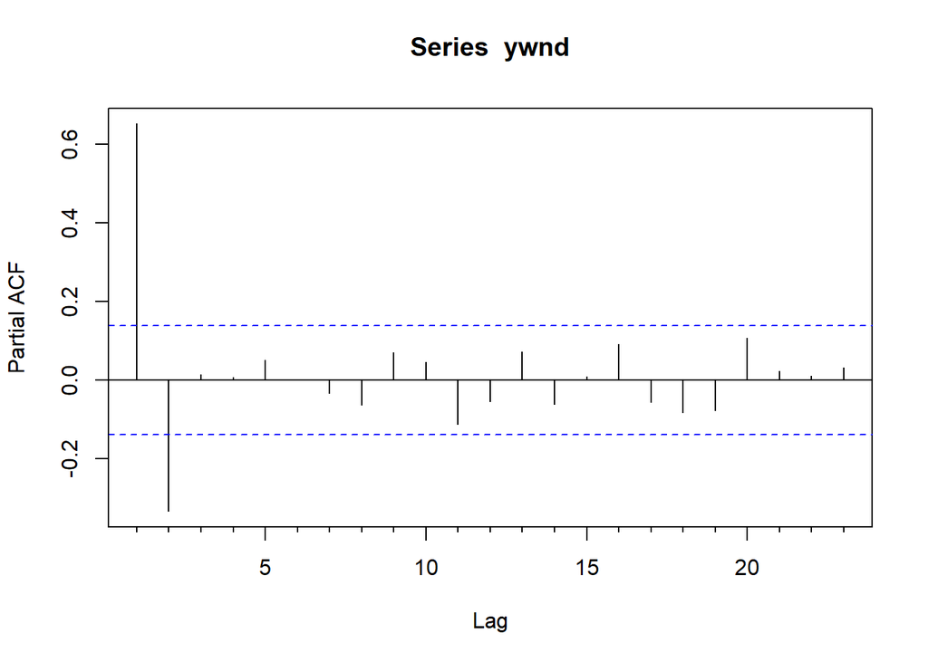

```r
Pacf(ywnd)
```

Auto-correlation can be noticed only in lag 1 and lag 2 in the ACF, whereas with the PACF we can see that there is significant correlation with the residuals at lag 1 and lag2,followed by non significant correlation showing an auto-regressive pattern. The pacf has two bar above the significance line, which indicated its an AR2 model. With PACF one bar close to 0.65 and the other is close to negative 0.3.

#### Question1(e)

##### e.MA(1) with parameter, 1 = 0.6

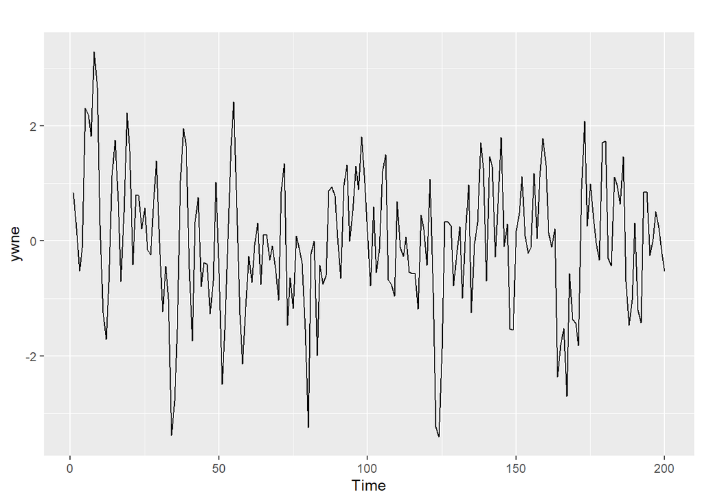

```r
ywne <- ts(data.frame(matrix(rep(0),200,1)))
ywne[1,1] <- wn[1]
for (i in 2:200) {
  ywne[i,1] <- wn[i] + 0.6*wn[i-1]
}
autoplot(ywne)
```

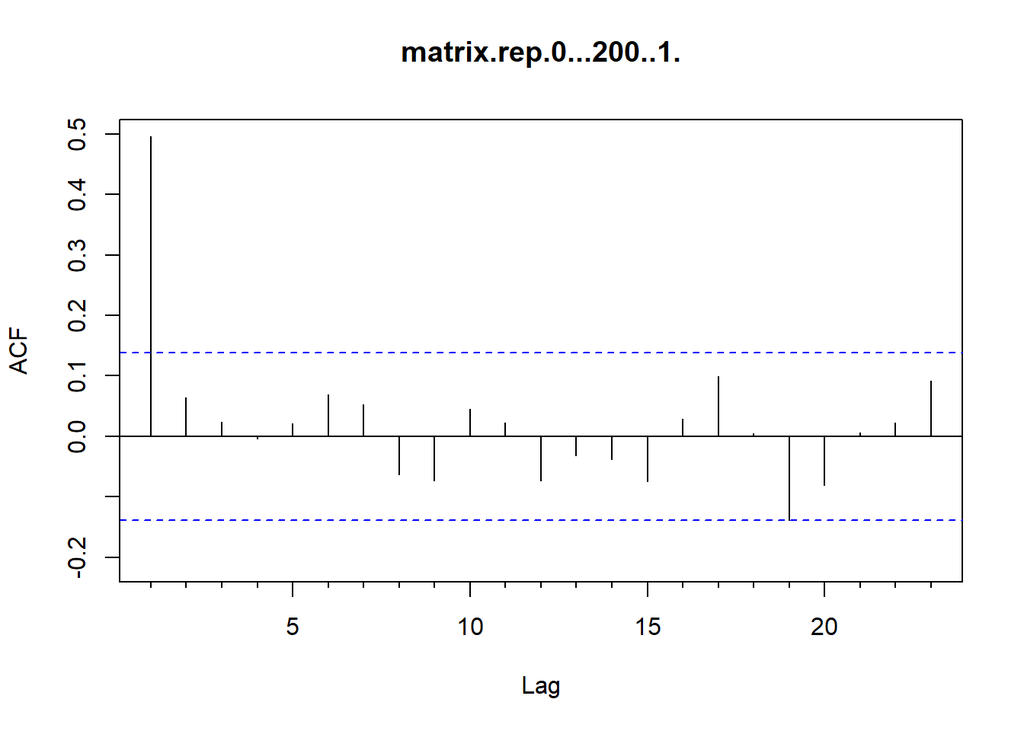

```r
#
#  Check Acf and Pacf
#
Acf(ywne)
```

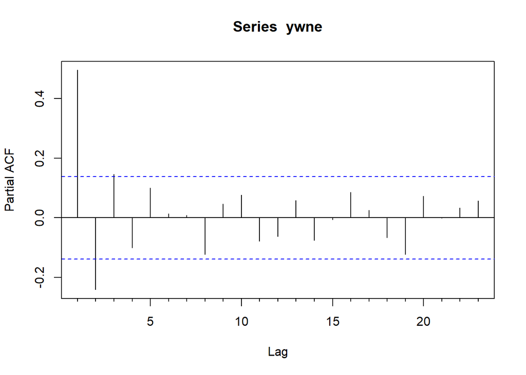

```r
Pacf(ywne)
```

The ACF plot show one bar above the significance line, which indicates this a MA(1) model with bar value at 0.5 level. For the PACF graph, there is a significance from lag 1 to 3, alternating between positive and negative, showing moving average term, the order of term is determined by the ACF function. In the ACF graph, only first the lag is significant, and the rest are not, showing poor auto-correlation.

#### Question1(f)

##### f.ARMA(1,1) with parameters, 1 = 0.5 and 1 = 0.4

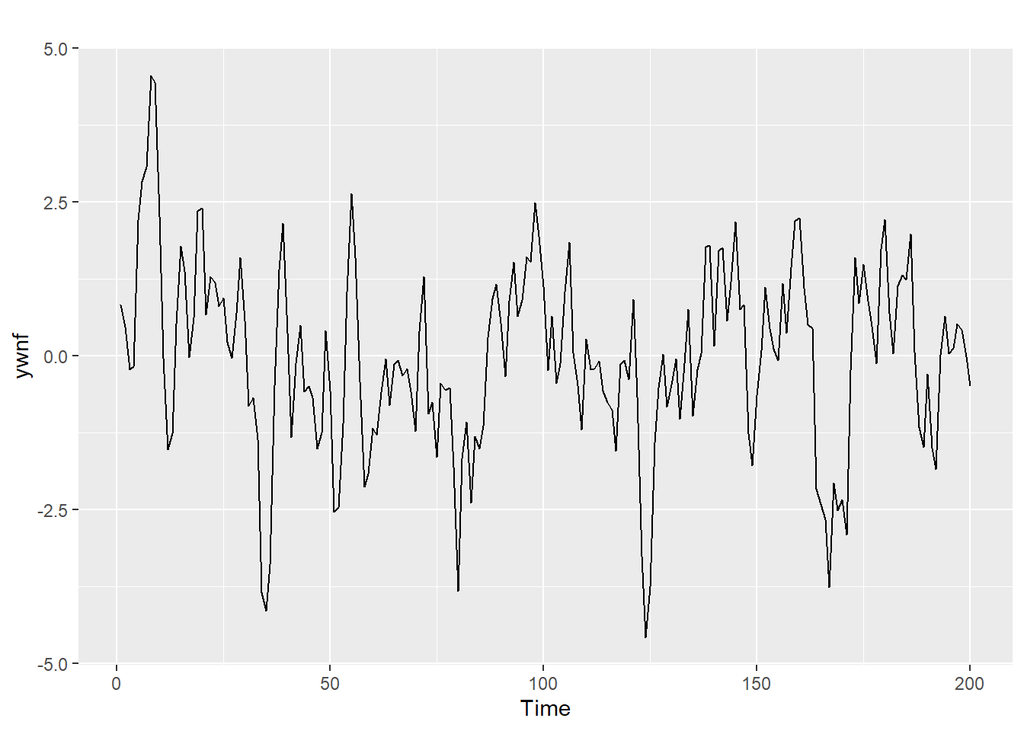

```r
ywnf <- ts(data.frame(matrix(rep(0),200,1)))
ywnf[1,1] <- wn[1]
for (i in 2:200) {
  ywnf[i,1] <- 0.5*ywnf[i-1,1] + 0.4*wn[i-1] + wn[i]
}
autoplot(ywnf)
```

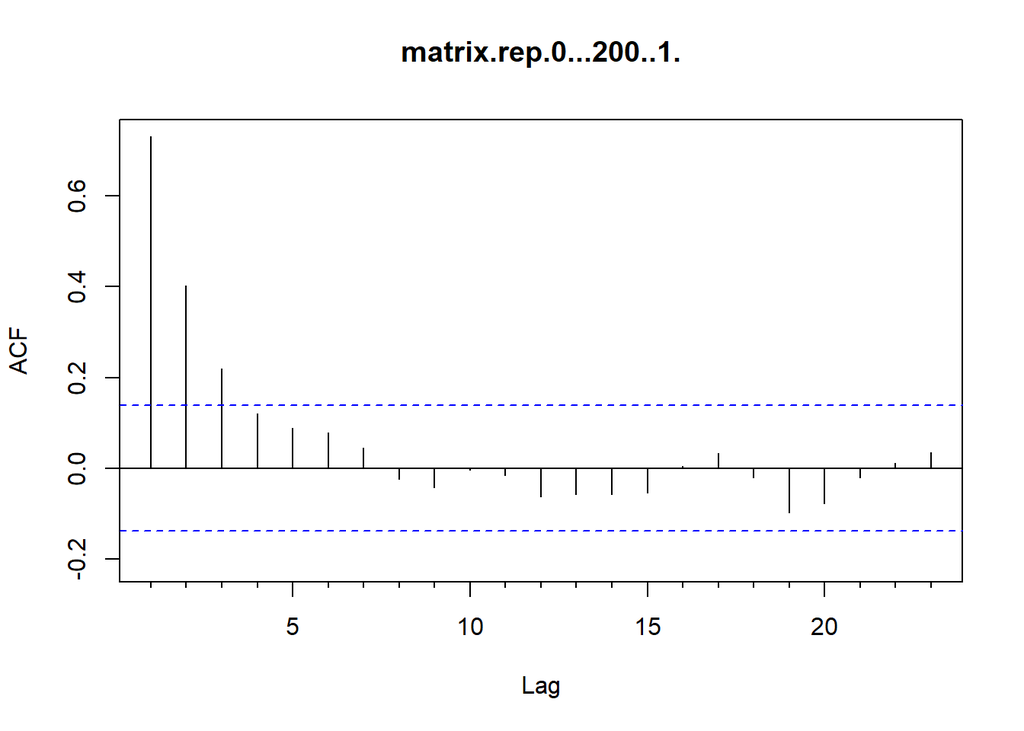

```r
#
#  Check Acf and Pacf
#
Acf(ywnf)
```

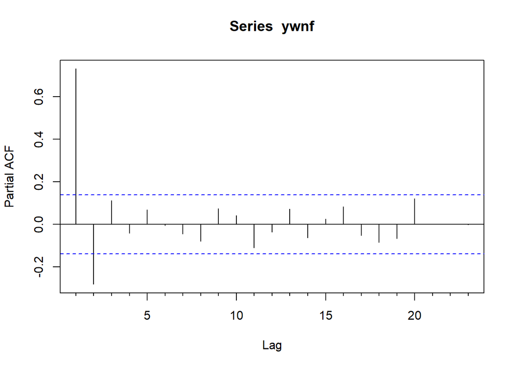

```r
Pacf(ywnf)
```

#### Question1(g)

##### g.ARIMA(1,1,1) with parameters, 1 = 0.5 and 1 = 0.4

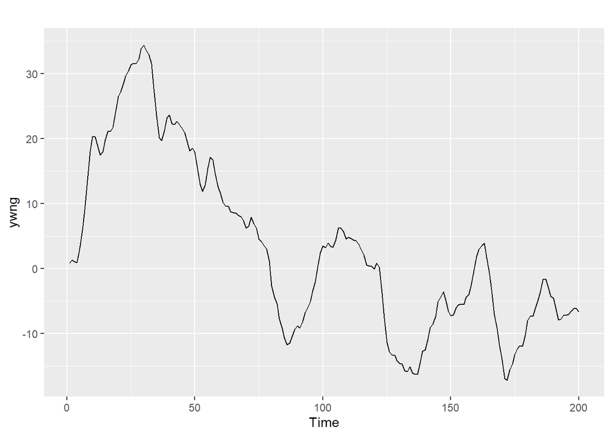

```r
ywng <- ts(data.frame(matrix(rep(0),200,1)))
ywng[1,1] <- wn[1]
for (i in 2:200){
  ywng[i,] <- ywng[i-1,] + ywnf[i,]
}

autoplot(ywng)
```

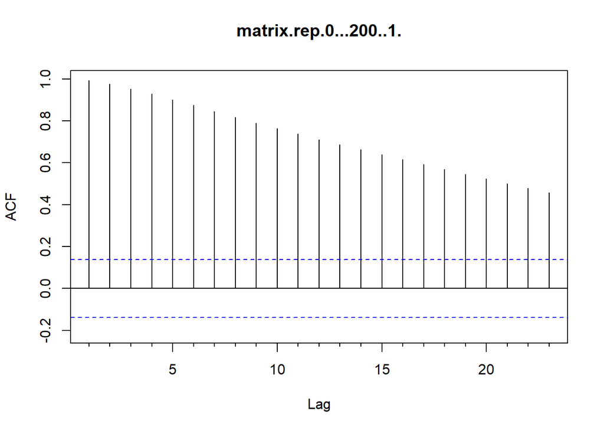

```r
Acf(ywng)
```

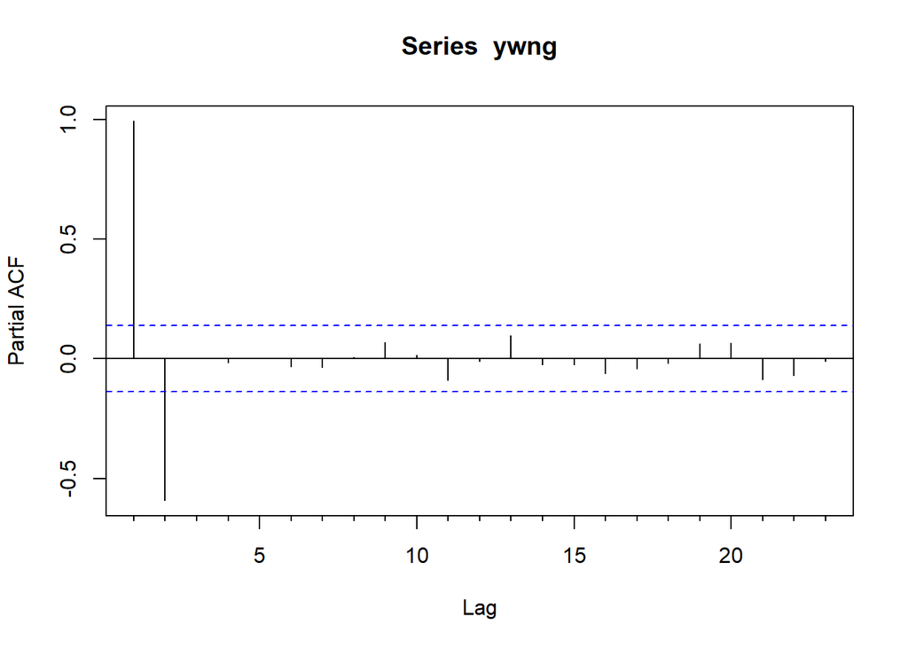

```r
Pacf(ywng)
```

All the lags for this model have high significant lags showing high autocorrelation, whereas the PACF graph is similar as previous and shows significant correlations from the lag 1 to lag 2, and then correlations that are not significant, and shows presence of an auto-regressive term in the data.

#### Question1(h)

#### h.ARIMA(1,1,1)(0,1,0)[4] with parameters, 1 = 0.5 and 1 = 0.4

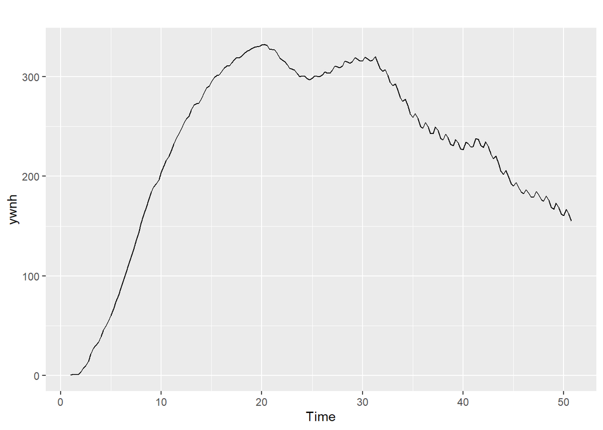

```r
ywnh <- ts(ywng, frequency = 4)

for (i in 5:200){
  ywnh[i] <- ywng[i] + ywnh[i-4]
}

autoplot(ywnh)
```

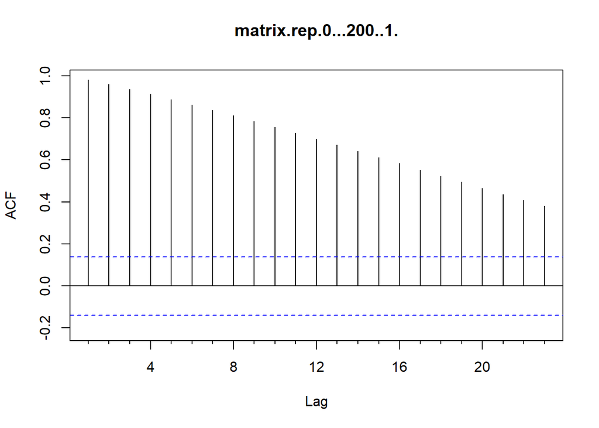

```r
Acf(ywnh)
```

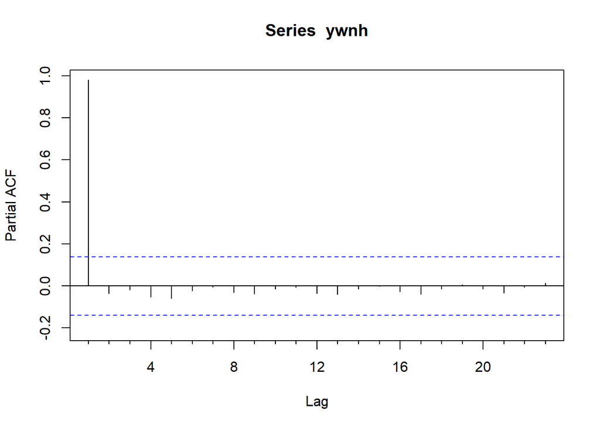

```r
Pacf(ywnh)
```

In this model all the ACF lags have high correlation showing high auto-correlation. And in the PACF there is only one bar that is significant, showing a high auto-regressive term which can be due to the presence of seasonality.

#### Question2(a)

#### reading in data and transforming it

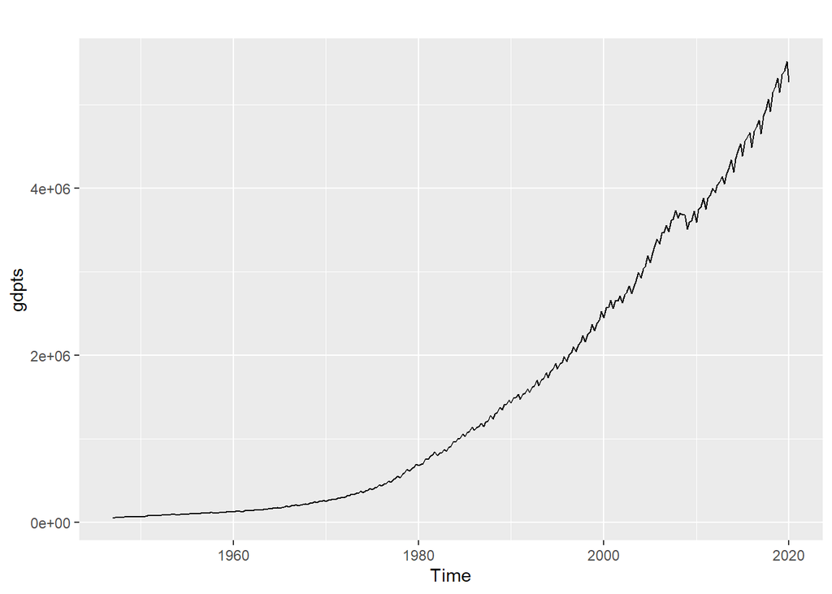

```r
data1 <- read.csv('hw6_USGDP.csv')
gdpts <- ts(data1[,2], start = 1947, frequency = 4)
autoplot(gdpts)
```

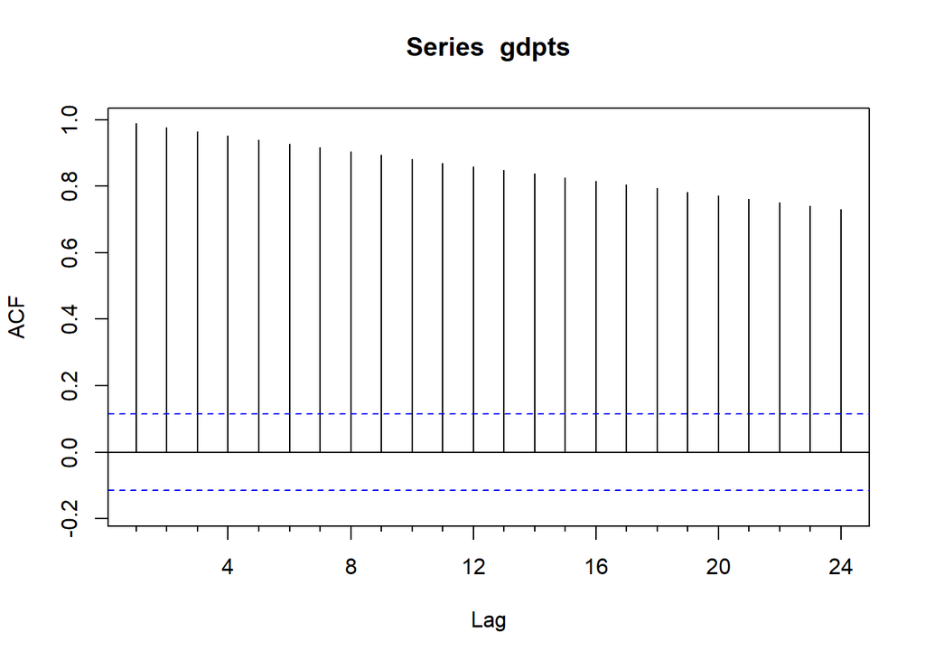

```r
Acf(gdpts)
```

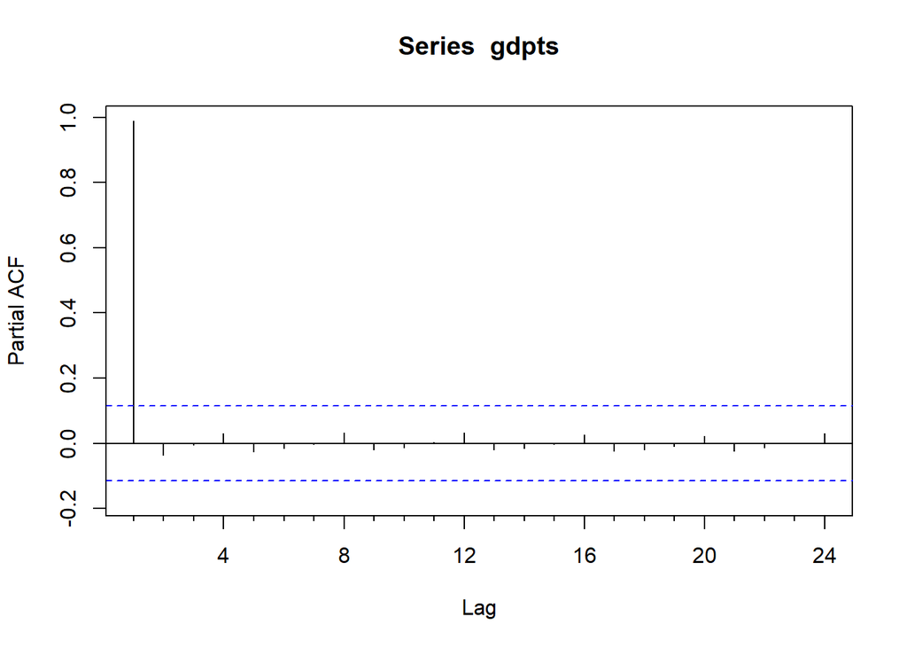

```r
Pacf(gdpts)
```

```r
Box.test(gdpts, lag = 1)
```

```
##
##  Box-Pierce test
##
## data:  gdpts
## X-squared = 286.21, df = 1, p-value < 2.2e-16
```

```r
# Data is correlated in time due to low p-value, so null hypothesis is rejected
Box.test(gdpts, lag = 12)
```

```
##
##  Box-Pierce test
##
## data:  gdpts
## X-squared = 2998.9, df = 12, p-value < 2.2e-16
```

```r
lambda <- BoxCox.lambda(gdpts)
lambda
```

```
## [1] 0.2351377
```

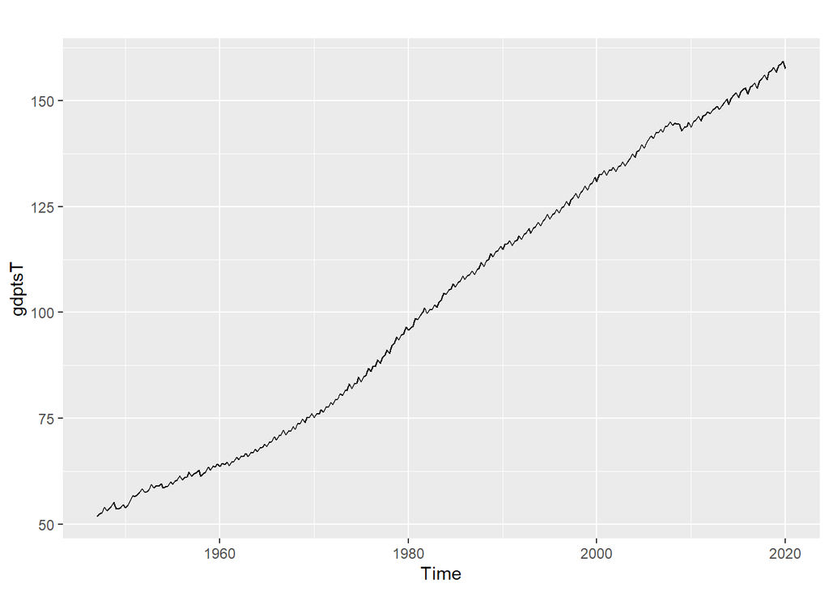

```r
#transformed data
gdptsT <- BoxCox(gdpts, BoxCox.lambda(gdpts))
autoplot(gdptsT)
```

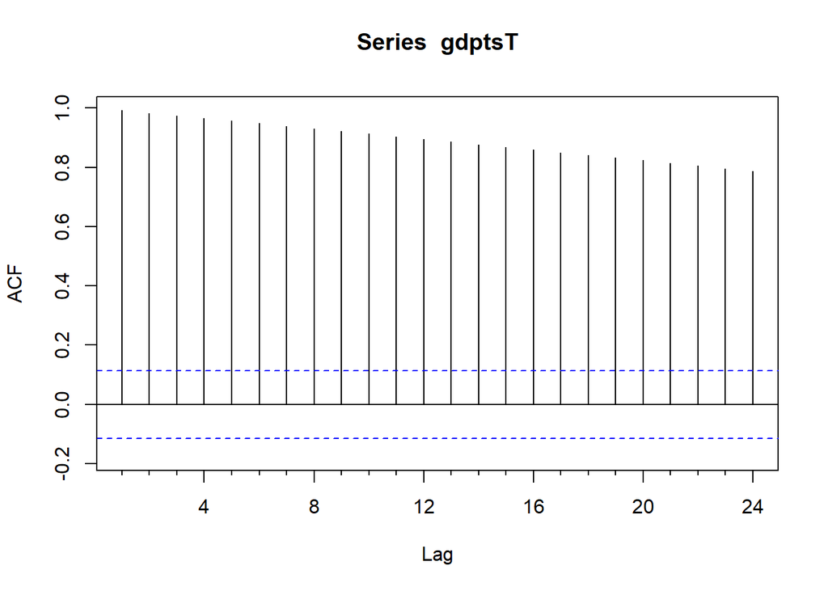

```r
Acf(gdptsT)
```

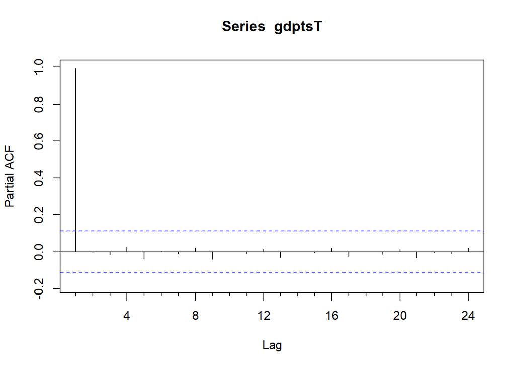

```r
Pacf(gdptsT)
```

#### Question2(b)

#### Running auto ARIMA for model selection

```r
model2b <- auto.arima(gdptsT)
sum2b <- summary(model2b)
```

```
## Series: gdptsT
## ARIMA(3,1,2)(0,1,2)[4]
##
## Coefficients:
##          ar1      ar2      ar3      ma1     ma2     sma1     sma2
##       1.3778  -0.8354  -0.0272  -1.1609  0.6984  -0.4152  -0.3045
## s.e.  0.1215   0.1784   0.0939   0.1068  0.1173   0.0755   0.0696
##
## sigma^2 estimated as 0.0604:  log likelihood=-2.47
## AIC=20.94   AICc=21.46   BIC=50.25
##
## Training set error measures:
##                       ME      RMSE       MAE         MPE      MAPE      MASE
## Training set 0.002366262 0.2406697 0.1790308 0.006033718 0.1969884 0.1198308
##                      ACF1
## Training set 0.0006230479
```

```r
aic2b <- model2b$aic
RMSE2b <- sum2b[2]
#The AIC is 20.94
# The RMSE is 0.2407
```

#### Question2(c)

#### Using diffrent p & q values and seeing ARIMA performance

```r
model2c1 <- arima(gdptsT, order = c(1,1,1), seasonal = list(order=c(0,1,2),period=4))
summary(model2c1)
```

```
##
## Call:
## arima(x = gdptsT, order = c(1, 1, 1), seasonal = list(order = c(0, 1, 2), period = 4))
##
## Coefficients:
##          ar1      ma1     sma1     sma2
##       0.4028  -0.1487  -0.5985  -0.1395
## s.e.  0.1487   0.1576   0.0611   0.0587
##
## sigma^2 estimated as 0.06368:  log likelihood = -13.52,  aic = 37.04
##
## Training set error measures:
##                       ME      RMSE       MAE         MPE      MAPE      MASE
## Training set 0.001268734 0.2502788 0.1866316 0.004211977 0.2068175 0.2262614
##                      ACF1
## Training set -0.005819879
```

```r
model2c2 <- arima(gdptsT, order = c(2,1,2), seasonal = list(order=c(0,1,2),period=4))
summary(model2c2)
```

```
##
## Call:
## arima(x = gdptsT, order = c(2, 1, 2), seasonal = list(order = c(0, 1, 2), period = 4))
##
## Coefficients:
##           ar1     ar2     ma1     ma2     sma1     sma2
##       -0.5959  0.1314  0.8449  0.1553  -0.6428  -0.1250
## s.e.   0.3832  0.4392  0.3839  0.4555   0.0819   0.0707
##
## sigma^2 estimated as 0.06279:  log likelihood = -11.56,  aic = 37.13
##
## Training set error measures:
##                       ME      RMSE       MAE         MPE      MAPE      MASE
## Training set 0.002007222 0.2485299 0.1842048 0.005431447 0.2034084 0.2233194
##                      ACF1
## Training set 0.0008176909
```

```r
model2c3 <- arima(gdptsT, order = c(2,1,1), seasonal = list(order=c(0,1,2),period=4))
summary(model2c3)
```

```
##
## Call:
## arima(x = gdptsT, order = c(2, 1, 1), seasonal = list(order = c(0, 1, 2), period = 4))
##
## Coefficients:
##           ar1     ar2     ma1     sma1     sma2
##       -0.5009  0.2772  0.7435  -0.6334  -0.1320
## s.e.   0.1938  0.0623  0.1928   0.0632   0.0599
##
## sigma^2 estimated as 0.06286:  log likelihood = -11.69,  aic = 35.38
##
## Training set error measures:
##                       ME     RMSE       MAE         MPE      MAPE      MASE
## Training set 0.001789113 0.248657 0.1846278 0.005100018 0.2037839 0.2238322
##                     ACF1
## Training set 0.007019866
```

#### Question2d

#### Checking residule from best ARIMA model

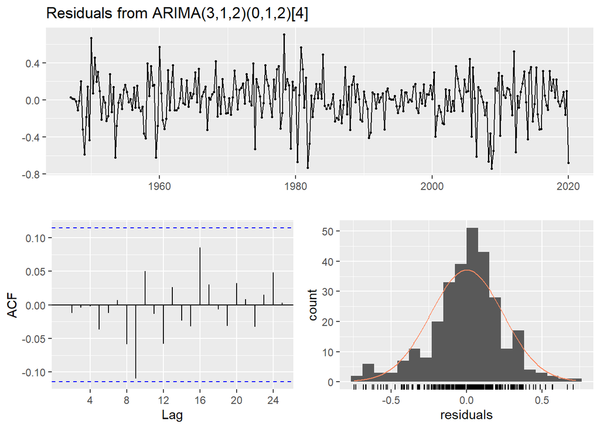

```
##
##  Ljung-Box test
##
## data:  Residuals from ARIMA(3,1,2)(0,1,2)[4]
## Q* = 5.9899, df = 3, p-value = 0.1121
##
## Model df: 7.   Total lags used: 10
```

```r
checkresiduals(model2b) # there is no correlation
```

As we can see from the plot, the residue looks like white noise,the ACF plot doesn’t have any lags that are significantly correlated and teh residule distribution looks like a normal distribution. All this indicates that the model fits really well and we just have white noise unexplained.